# Transcriptómica espacial de datos de cerebro

Diana Barrientos, Román Cervantes, Yuliana Sosa

2026-10-28

## 1 Descarga del dataset

```r
getwd()
```

```
## [1] "/Users/romaan/brain_cancer_data"
```

```r
# Los archivos ya se descargaron desde la terminal con wget, dentro de:
# /Users/romaan/brain_cancer_data/glioblastoma_data/
#desde la terminal cree el directorio brain_cancer_data donde se encuentra este Rmd y también el subdirectorio glioblastoma_data donde están cargados los datos con wget:
# get https://cf.10xgenomics.com/samples/spatial-exp/2.0.1/CytAssist_11mm_FFPE_Human_Glioblastoma/CytAssist_11mm_FFPE_Human_Glioblastoma_filtered_feature_bc_matrix.tar.gz
#wget https://cf.10xgenomics.com/samples/spatial-exp/2.0.1/CytAssist_11mm_FFPE_Human_Glioblastoma/CytAssist_11mm_FFPE_Human_Glioblastoma_spatial.tar.gz

# Dataset: https://www.10xgenomics.com/datasets/11mm-capture-area-ffpe-human-glioblastoma-probe-based-whole-transcriptome-profiling-1-standard

# knitr usa como directorio de trabajo la carpeta del Rmd (brain_cancer_data/).
# Para correr esto, hay que asegurarse de estar en (con getwd puedes ver dónde estás parado):
# setwd("/Users/romaan/brain_cancer_data")
getwd()
```

```
## [1] "/Users/romaan/brain_cancer_data"
```

```r
data_dir <- "glioblastoma_data/"
list.files(data_dir)   # deben aparecer los dos .tar.gz
```

```
## [1] "CytAssist_11mm_FFPE_Human_Glioblastoma_filtered_feature_bc_matrix.tar.gz"
## [2] "CytAssist_11mm_FFPE_Human_Glioblastoma_spatial.tar.gz"
## [3] "filtered_feature_bc_matrix"
## [4] "scRNA_mouse_brain"
## [5] "spatial"
```

```r
# DescomprimIr los archivos (se crean las carpetas dentro de glioblastoma_data/)
untar(tarfile = file.path(data_dir, "CytAssist_11mm_FFPE_Human_Glioblastoma_filtered_feature_bc_matrix.tar.gz"),
      exdir = data_dir)

untar(tarfile = file.path(data_dir, "CytAssist_11mm_FFPE_Human_Glioblastoma_spatial.tar.gz"),
      exdir = data_dir)

# Reviso que quedó todo en su lugar
list.files(data_dir)
```

```
## [1] "CytAssist_11mm_FFPE_Human_Glioblastoma_filtered_feature_bc_matrix.tar.gz"
## [2] "CytAssist_11mm_FFPE_Human_Glioblastoma_spatial.tar.gz"
## [3] "filtered_feature_bc_matrix"
## [4] "scRNA_mouse_brain"
## [5] "spatial"
```

```r
list.files(file.path(data_dir, "filtered_feature_bc_matrix"))
```

```
## [1] "barcodes.tsv.gz" "features.tsv.gz" "matrix.mtx.gz"
```

```r
list.files(file.path(data_dir, "spatial"))
```

```
## [1] "aligned_fiducials.jpg"     "aligned_tissue_image.jpg"
## [3] "cytassist_image.tiff"      "detected_tissue_image.jpg"
## [5] "scalefactors_json.json"    "spatial_enrichment.csv"
## [7] "tissue_hires_image.png"    "tissue_lowres_image.png"
## [9] "tissue_positions.csv"
```

Para descomprimir alternativa: Otra opción es hacerlo desde la terminal, parado en `/Users/romaan/brain_cancer_data/glioblastoma_data`:

```bash
tar -xzf CytAssist_11mm_FFPE_Human_Glioblastoma_filtered_feature_bc_matrix.tar.gz
tar -xzf CytAssist_11mm_FFPE_Human_Glioblastoma_spatial.tar.gz
```

```r
library(Giotto)

instructions <- createGiottoInstructions(save_dir = "visium_plots", #guardaremos las imágenes en este directorio
                                         save_plot = TRUE,
                                         show_plot = TRUE,
                                         return_plot = FALSE,
                                         python_path = NULL # alternativamente, "/local/python/path/python"
                                         )
```

## 2 Crear el objeto Giotto

Se lee la carpeta de Visium y se arma un objeto con la matriz de cuentas, las coordenadas, los metadatos y la imagen del tejido.

```r
data_path <- "glioblastoma_data/"

visium_brain_old <- createGiottoVisiumObject(visium_dir = data_path, ##le damos el path necesario de visum, utiliza la matriz de cuentas + coordenadas de spots y metadatos para armar este objeto
                                         expr_data = "filter", #usa la matriz de expresion filtrada
                                         png_name = "tissue_lowres_image.png", #indica la imagen del tejido que se debe asociar al los datos para darle contexto espacial
                                         gene_column_index = 2, #os genes están en la segunda columna del archivo de feaatures
                                         instructions = instructions) #llama la config de arriba que hicimos para las imágenes
```

## 3 Alternativa

Otra forma de armar el mismo objeto, pero desde la matriz con get10Xmatrix, las coordenadas desde un csv y los metadatos desde otro csv. Sirve cuando mis datos no vienen en la estructura estándar de Space Ranger (por ejemplo vienen de otro pipeline).

```r
# Crea la matriz de expresión
expression_matrix <- get10Xmatrix("glioblastoma_data/filtered_feature_bc_matrix/",
                                  gene_column_index = 2) ##digo en que columna se encuentran los genes y en esta variable se gaurdará el resultado, son todos los barcodes incluso no los filtrados

# le doy la info espacial:
spatial_results <- data.table::fread("glioblastoma_data/spatial/tissue_positions.csv")  #convierte en tabla
colnames(spatial_results) <- c(
    "cell_ID", "in_tissue", "array_row",
    "array_col", "col_pxl", "row_pxl"
) #explica que es cada columna y las nombra
```

Al hacer esto, tuvimos un error donde las coordenadas espaciales no coinciden con el número de identificadores celulares de la matriz de expresión, por lo tanto, hacemos lo siguiente para filtrar las coordenadas y que coincidan:

```r
# Conserva únicamente las posiciones que aparecen en la matriz
spatial_results <- spatial_results[
    cell_ID %in% colnames(expression_matrix)
]

# Comprueba que ahora coincidan
nrow(spatial_results)
```

```
## [1] 10878
```

```r
ncol(expression_matrix)
```

```
## [1] 10878
```

Ahora tienen la misma dimensión y podemos seguir con spatial locs:

```r
# Crea las coordenadas
spatial_locs <- spatial_results[, .(
    cell_ID,
    sdimx = row_pxl,
    sdimy = -col_pxl #dénde esta cada spot
)]

# Crea los metadatos
cell_metadata <- spatial_results[, .(
    cell_ID,
    in_tissue
)] #características de cada spot
```

Al ya no tener error, podemos seguir:

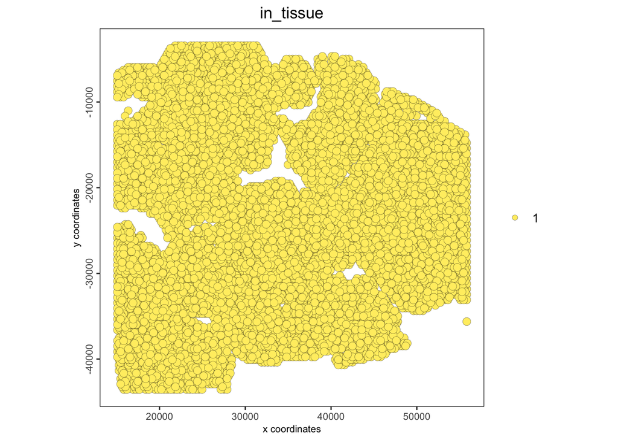

```r
# Crea el objeto
visium_object <- createGiottoObject(expression = expression_matrix, #incorpora los conteos de expresión génica
                                    spatial_locs = spatial_locs) #coordenadas espaciales

visium_object <- addCellMetadata(visium_object, #añade metadados al objeto existente
                                 new_metadata = cell_metadata,
                                 by_column = TRUE) #los identificadores de los spots se utilizan para asociar los metadatos con las unidades espaciales del objeto

spatPlot2D(visium_object, #objeto a visualizar
           cell_color = "in_tissue") #asigna colorcitos a spots
```

## 4 Ver el objeto

```r
visium_object
```

```
## An object of class giotto
## >Active spat_unit:  cell
## >Active feat_type:  rna
## dimensions    : 18076, 10878 (features, cells)
## [SUBCELLULAR INFO]
## [AGGREGATE INFO]
## expression -----------------------
##   [cell][rna] raw
## spatial locations ----------------
##   [cell] raw
##
##
## Use objHistory() to see steps and params used
```

```r
# ver la matriz de expresión
showGiottoExpression(visium_object)
```

```
## └──Spatial unit "cell"
##    └──Feature type "rna"
##       └──Expression data "raw" values:
##             An object of class exprObj : "raw"
##             spat_unit : "cell"
##             feat_type : "rna"
##             provenance: cell
##
##             contains:
##             18076 x 10878 sparse Matrix of class "dgTMatrix"
##
##             SAMD11 . 1 . . . . . . . . . . ......
##             NOC2L  2 3 . . . . . 1 1 . . . ......
##             KLHL17 1 . . . . . . . . . . . ......
##
##              ........suppressing 10866 columns and 18070 rows
##
##             MT-ND5 17  59  8 17 46 36 25  57  57 13 12 25
##             MT-ND6 17  29 11 13 20 19 13  43  37 13 12 18
##             MT-CYB 52 117 14 23 60 43 33 109 124 39 21 49
##
##             MT-ND5 ......
##             MT-ND6 ......
##             MT-CYB ......
##
##              First four colnames:
##              AACAATCCGAGTGGAC-1 AACAATGTGCTCCGAG-1
##              AACAATTATCTGCGCC-1 AACACCAGCCTACTCG-1
##
```

```r
# muestra metadatos por spot
showGiottoCellMetadata(visium_object)
```

```
## └──Spatial unit "cell"
##    └──Feature type "rna"
##          An object of class cellMetaObj
##          spat_unit : "cell"
##          feat_type : "rna"
##          provenance: cell
##          dimensions: 4 2
##
##          Key: <cell_ID>
##                        cell_ID in_tissue
##                         <char>     <int>
##          1: AACAATCCGAGTGGAC-1         1
##          2: AACAATGTGCTCCGAG-1         1
##          3: AACAATTATCTGCGCC-1         1
##
```

Aquí se busca cuántos spots y genes hay, qué matrices existen y qué columnas trae el metadato. Podemos ver que las moléculas son de RNA por ejemplo.

### 4.1 Exportar y reimportar metadatos y coordenadas

Sr guardan los metadatos del objeto viejo en un csv, los vuelvo a leer y se agregan a visium_object.

```r
cell_metadata <- pDataDT(visium_brain_old)  #obtiene la tabla de metadatos asociados al objeto visium_brain_old

write.csv(cell_metadata, "cell_metadata.csv", #csv que se lee
          quote = FALSE, row.names = TRUE)

cell_metadata <- read.csv("cell_metadata.csv", #lee el archivo recién creado
                          header = TRUE, row.names = 1)

visium_object <- addCellMetadata(visium_object, #añadimos metadata a este nuevo objeto
                                new_metadata = cell_metadata, #col spots, filas info genes, transcritos
                                by_column = TRUE)

getCellMetadata(visium_object) #comprueba mi metadata
```

```
## An object of class cellMetaObj
## spat_unit : "cell"
## feat_type : "rna"
## provenance: cell
## dimensions: 10878 4
##
## Key: <cell_ID>
##               cell_ID in_tissue array_row array_col
##                <char>     <int>     <int>     <int>
## 1: AACAATCCGAGTGGAC-1         1       103        47
## 2: AACAATGTGCTCCGAG-1         1        98       158
## 3: AACAATTATCTGCGCC-1         1        37       219
```

```r
pDataDT(visium_object) #imprime la tabla de metadatos
```

```
## Key: <cell_ID>
##                   cell_ID in_tissue array_row array_col
##                    <char>     <int>     <int>     <int>
##     1: AACAATCCGAGTGGAC-1         1       103        47
##     2: AACAATGTGCTCCGAG-1         1        98       158
##     3: AACAATTATCTGCGCC-1         1        37       219
##     4: AACACCAGCCTACTCG-1         1        31        39
##     5: AACACCATTCGCATAC-1         1        53       139
##    ---
## 10874: TGTTGGCCTGTAGCGG-1         1        40        78
## 10875: TGTTGGTGATTAGGTA-1         1       108        22
## 10876: TGTTGGTGCGCACGAG-1         1        24       108
## 10877: TGTTGGTGCGCTTCGC-1         1        37       127
## 10878: TGTTGGTGCGGAATCA-1         1        83        87
```

```r
spatial_locs <- getSpatialLocations(visium_brain_old,
                                    output = "data.table") # escribe dónde está cada spot

write.csv(spatial_locs, "spatial_locs.csv", quote = FALSE,
          row.names = FALSE) #lo guarda en archivo csv
```

El csv debería tener: ID del spot y coordenadas X, Y.

### 4.2 Genes, imágenes y redducción

Primero se comprueba: metadatos de genes, nombres de imágenes guardadas, reducciones de dimensión existentes e instrucciones del objeto.

```r
# Metadatos de los genes/proteínas
showGiottoFeatMetadata(visium_object)
```

```
## └──Spatial unit "cell"
##    └──Feature type "rna"
##          An object of class featMetaObj
##          spat_unit : "cell"
##          feat_type : "rna"
##          provenance: cell
##
##             feat_ID
##              <char>
##          1:  SAMD11
##          2:   NOC2L
##          3:  KLHL17
##
```

```r
# Imágenes
showGiottoImageNames(visium_object) #muestra las imagenes, por problema de terra no se renderiza
```

```
## No available images
```

```r
# Reducción de dimensiones
showGiottoDimRed(visium_object) # Reducción de dimensiones que no se visualiza por los errores
```

```
## No dimensional reductions available
```

```r
# Instrucciones
instructions(visium_object)
```

```
## <giottoInstructions>
## python_path      : /Users/romaan/Library/r-miniconda-arm64/envs/giotto_env/bin/pythonw
## show_plot        : TRUE
## return_plot      : TRUE
## save_plot        : FALSE
## save_dir         : /Users/romaan/brain_cancer_data
## plot_format      : png
## dpi              : 300
## units            : in
## height           : 9
## width            : 9
## is_docker        : FALSE
## active_spat_unit : cell
## active_feat_type : rna
```

Metadatos de genes y reducciones estarán casi vacíos por ahora poruqe todavía no hay PCA.

## 5 Filtrar los spots que están sobre el tejido

Primero grafico todos los spots coloreados por in_tissue (gris = fuera de tejido, azul = sobre tejido). Luego tomo del metadato los barcodes con in_tissue == 1, hago un subconjunto y vuelvo a graficar para confirmar que solo quedan los azules.

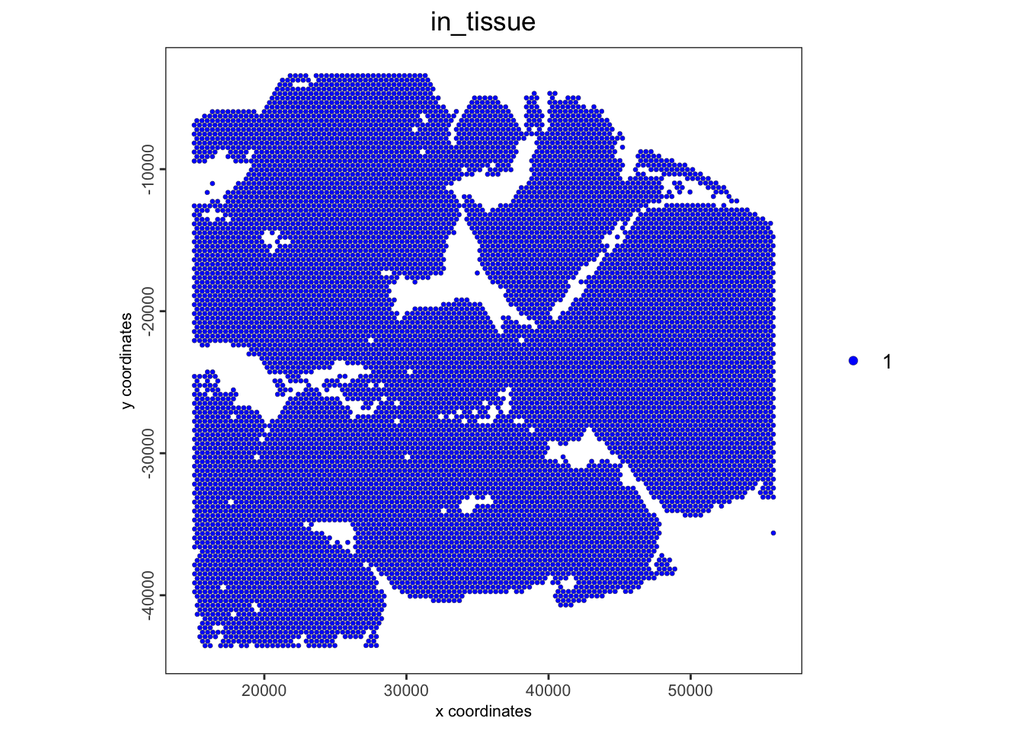

```r
spatPlot2D(gobject = visium_object, #crea una grafica en 2D, aqui se indica el objeto q tiene los datos
           cell_color = "in_tissue", #colorea losspots segun esta variable
           point_size = 1,
           cell_color_code = c("0" = "lightgrey", "1" = "blue"), #cuando es 0 pintará gris y si es 1 azul
           show_image = FALSE,
           image_name = "image")
```

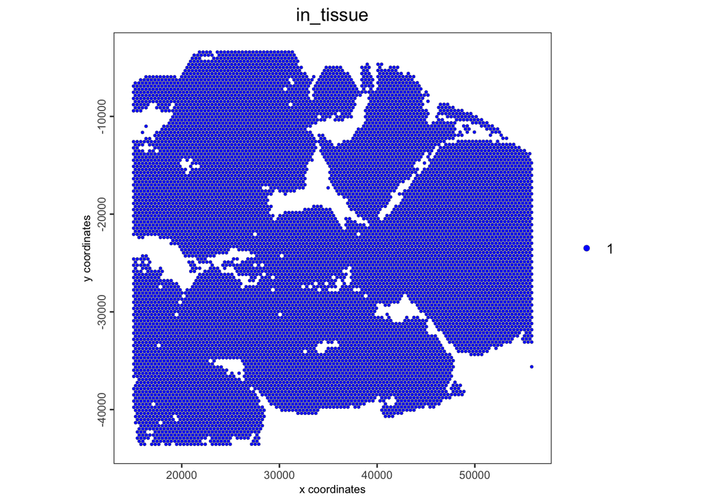

```r
cell_metadata <- pDataDT(visium_object) #obtener metadata del objeto
in_tissue_barcodes <- cell_metadata[in_tissue == 1]$cell_ID #solo queremos los spots que cuenten con tejhido

visium_brain <- subsetGiotto(visium_object,
                             cell_ids = in_tissue_barcodes) #crea un objeto únicamente con los spots que seleccionamos arriba, que termina siendo un subconjunto y se ponen los indicadores

spatPlot2D(gobject = visium_brain, #igual grafica en 2D pero con nuestro subset de interés, el nuevo objeto
           cell_color = "in_tissue",
           point_size = 1,
           cell_color_code = c("0" = "lightgrey", "1" = "blue"),
           show_image = FALSE,
           image_name = "image")
```

En nuestro caso, podemos ver que únicamente teníamos spots de color azul, lo cual significa que no hay spots que estén fuera del área indicada como tejido (azul).

Antes del control de calidad, veamos cuántas células tenemos:

```r
nrow(pDataDT(visium_brain))
```

```
## [1] 10878
```

## 6 Control de calidad

```r
# Crea un objecto con el número de genes y transcritos por spot
visium_brain_statistics <- addStatistics(gobject = visium_brain,
                                         expression_values = "raw")

pDataDT(visium_brain_statistics) #tabla de mis estadísticas
```

```
## Key: <cell_ID>
##                   cell_ID in_tissue array_row array_col nr_feats perc_feats
##                    <char>     <int>     <int>     <int>    <int>      <num>
##     1: AACAATCCGAGTGGAC-1         1       103        47     7397  40.921664
##     2: AACAATGTGCTCCGAG-1         1        98       158     8213  45.435937
##     3: AACAATTATCTGCGCC-1         1        37       219      938   5.189201
##     4: AACACCAGCCTACTCG-1         1        31        39     2732  15.113963
##     5: AACACCATTCGCATAC-1         1        53       139     5467  30.244523
##    ---
## 10874: TGTTGGCCTGTAGCGG-1         1        40        78     1472   8.143395
## 10875: TGTTGGTGATTAGGTA-1         1       108        22     2117  11.711662
## 10876: TGTTGGTGCGCACGAG-1         1        24       108    10113  55.947112
## 10877: TGTTGGTGCGCTTCGC-1         1        37       127     2554  14.129232
## 10878: TGTTGGTGCGGAATCA-1         1        83        87     6642  36.744855
##        total_expr
##             <num>
##     1:      21825
##     2:      30028
##     3:       1210
##     4:       3241
##     5:      11178
##    ---
## 10874:       1711
## 10875:       2843
## 10876:      43324
## 10877:       3456
## 10878:      17251
```

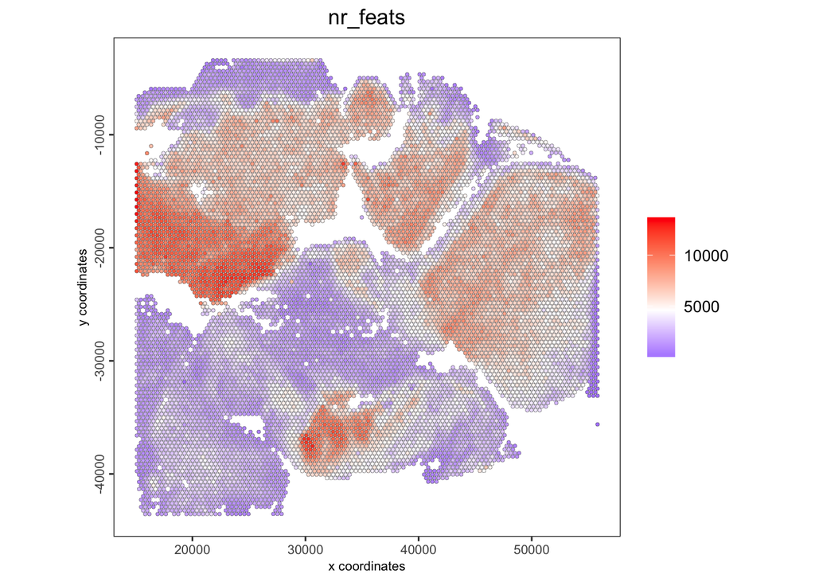

```r
spatPlot2D(gobject = visium_brain_statistics,
           cell_color = "nr_feats",
           point_size = 1,
           color_as_factor = FALSE) #objeto 2D pero ya tomando en cuenta mis genes y transcritos por spot
```

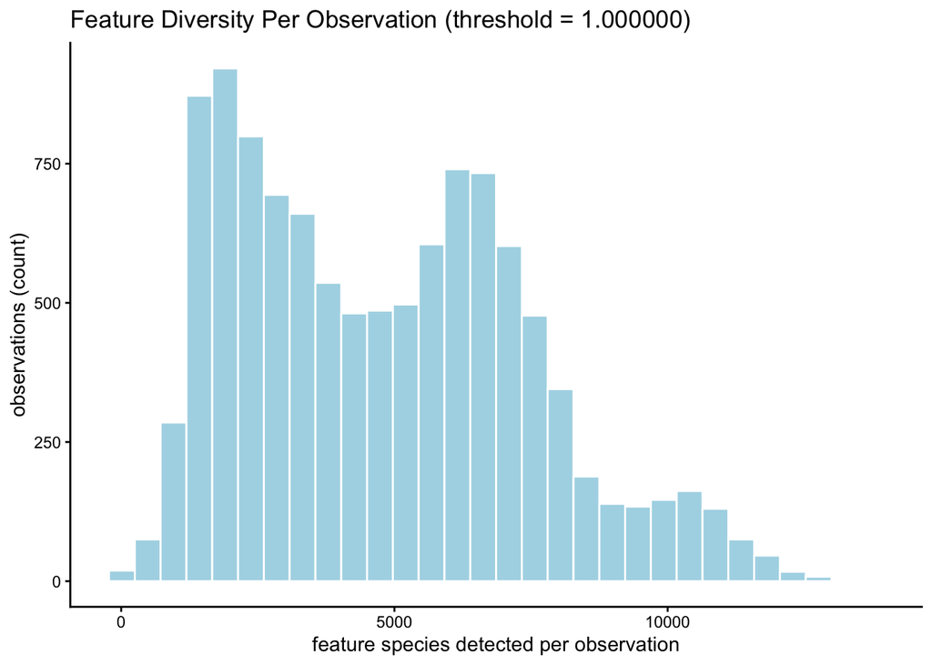

```r
# Distribución de genes por spot para detectar los que salen con valores bajos
filterDistributions(gobject = visium_brain_statistics,
                    detection = "cells")
```

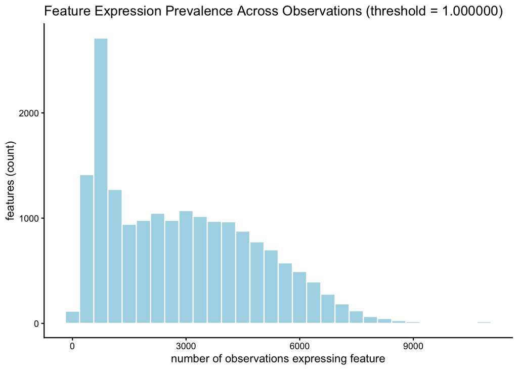

```r
# Distribución del número de features detectados por spots, para identificar spots con muy pocos genes o valores atípicos
filterDistributions(gobject = visium_brain_statistics,
                    detection = "feats")
```

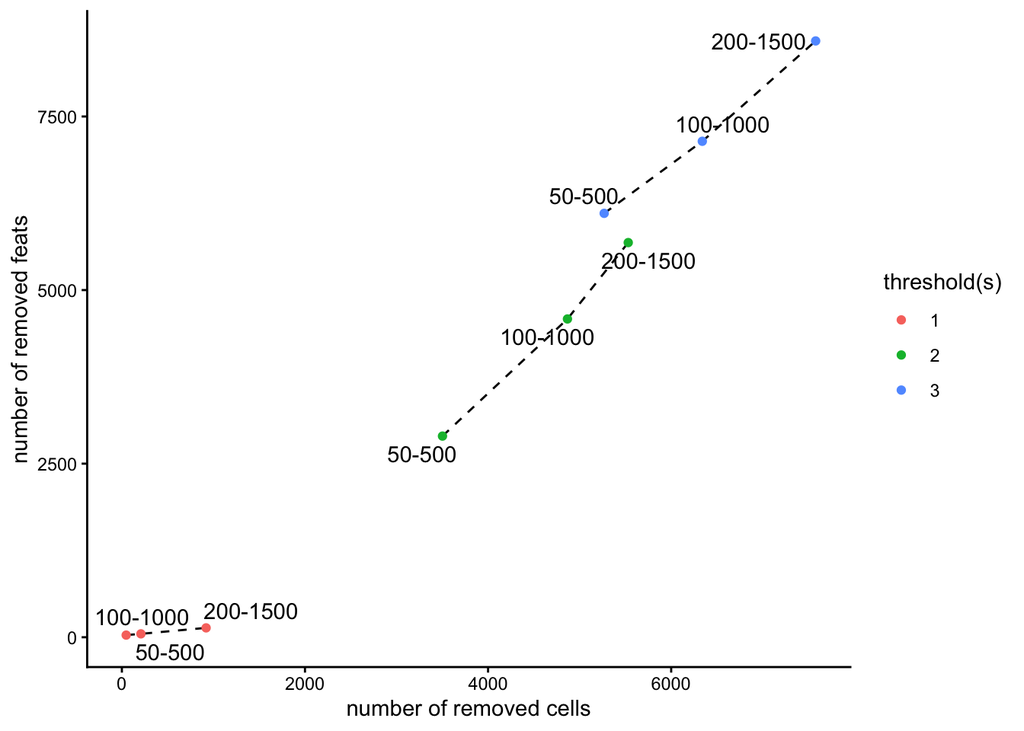

```r
# Evalúa diferentes puntos de corte al filtrar
filterCombinations(gobject = visium_brain_statistics, # evalúa distintas combinaciones de umbrales de filtrado para ver cómo afectan la cantidad de genes y spots que se conservan
                   expression_thresholds = c(1, 2, 3),
                   feat_det_in_min_cells = c(50, 100, 200),
                   min_det_feats_per_cell = c(500, 1000, 1500))
```

###Explicación de las gráficas: 1) pinta segun el número de genes diferentes detectados en cada spot, mientras mas rojitos mas genes diferentes detctados en es espot, mientras mas azulito menos genes diferentes 2) es la distribución de cuántos genes detecto por cada spot, valore smuy bajitos es que son spots con muy pocos genes detectados mientras que spots con valores muy altos tienen muchos genes detectados 3 ) que tantos spots presentan un feature que en este caso es cantidad de genes, un pico alto es que hay una gran cantidad de genes que solo se expresan en una cantidad pequeña de spots, hay genes que se expresan en gran cantidad de spots por lo cual estos pueden ser hosuekeeping 4) son todas las combinaciones posibles de cortes para filtrar, se busca un calance entre el numero de spots que se remueven con el numero de features o genes qeu se remueven por lo cual los clusters 1 y 3 son muy laxos y estrictos respectivamente, el cluster 2 serían valores con mejores thresholds

## 7 Filtrado

Un gen cuenta como detectado en un spot si tiene al menos 1 transcrito. Nos quedaremos solo con genes detectados en al menos 50 spots y solo con spots que tengan al menos 1000 genes detectados:

```r
#aquí aplicamos filtros mencionados en el párrafo de arriba
visium_brain <- filterGiotto(gobject = visium_brain,
                             expression_threshold = 1,
                             feat_det_in_min_cells = 50,
                             min_det_feats_per_cell = 1000,
                             expression_values = "raw",
                             verbose = TRUE)
```

```
##
## Feature type:  rna
## Number of cells removed:  208  out of  10878
## Number of feats removed:  31  out of  18076
```

Número de células tras filtrar po calidad:

```r
nrow(pDataDT(visium_brain))
```

```
## [1] 10670
```

## 8 Normalización

Escalamos cada spot a un total común (scalefactor = 6000) porque 6000 es el valor por defecto de Giotto. aplicamos transformación logarítmica y además generamos una versión escalada que más adelante se usa. Los resultados se guardan en el objeto junto con la matriz cruda.

```r
visium_brain <- normalizeGiotto(gobject = visium_brain,
                                scalefactor = 6000,
                                verbose = TRUE)
```

## 9 Estadísticas después de la normalización

Volvemos a calcular los estadísticos de antes pero ahora con el objeto ya filtrado y normalizado y graficamos el objeto por nr_feats, que permite ver diversidad de expresión génica en los spots. Un valor bajo puede reflejar poca cantidad de RNA

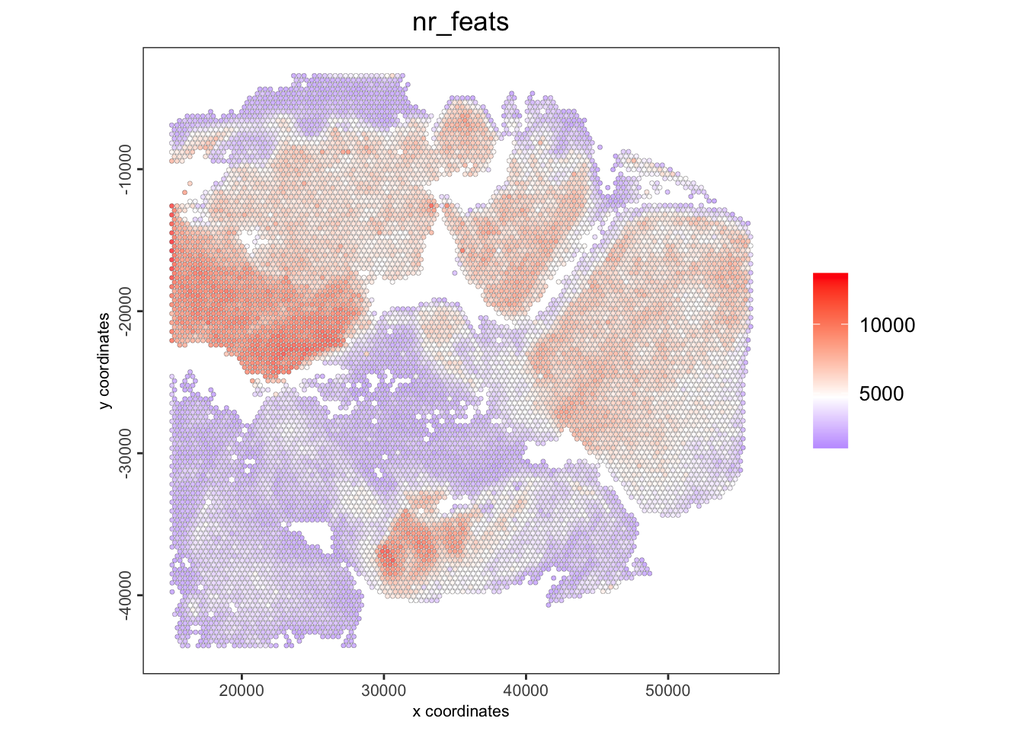

```r
visium_brain <- addStatistics(gobject = visium_brain)

spatPlot2D(gobject = visium_brain,
           show_image = FALSE,
           point_size = 1,
           point_alpha = 0.7,
           cell_color = "nr_feats",
           color_as_factor = FALSE)
```

Ahora los valores bajos deberían haber desaparecido y se observa más variación biológica real. En cerebro, regiones con más genes detectados suelen corresponder a neuronas, mientras que menos genes puede ser sustancia blanca.

## 10 Genes altamente variables (HVF)

```r
# Regresión de Loess es usada cuando la relación entre la expresión promedio
# y la varianza son no lineales o pueden ser descritas por un modelo no paramétrico

visium_brain <- calculateHVF(gobject = visium_brain,
                             method = "cov_loess",
                             save_plot = TRUE)

# Residuales Pearson son usados para la estabilización de la varianza
# (para lidiar con el ruido técnico) y resaltar los genes con alta dispersión

visium_brain <- calculateHVF(gobject = visium_brain,
                             method = "var_p_resid",
                             save_plot = TRUE)

# Grupos de covarianza (default), son usagos cuando la variabilidad de la expresión
# difiere a través de los niveles de expresión o las regiones espaciales, sin
# asumir una relación específica entre la expresión promedio y la varianza.

visium_brain <- calculateHVF(gobject = visium_brain,
                             method = "cov_groups",
                             save_plot = TRUE)
```

## 11 Reducción de dimensiones: PCA

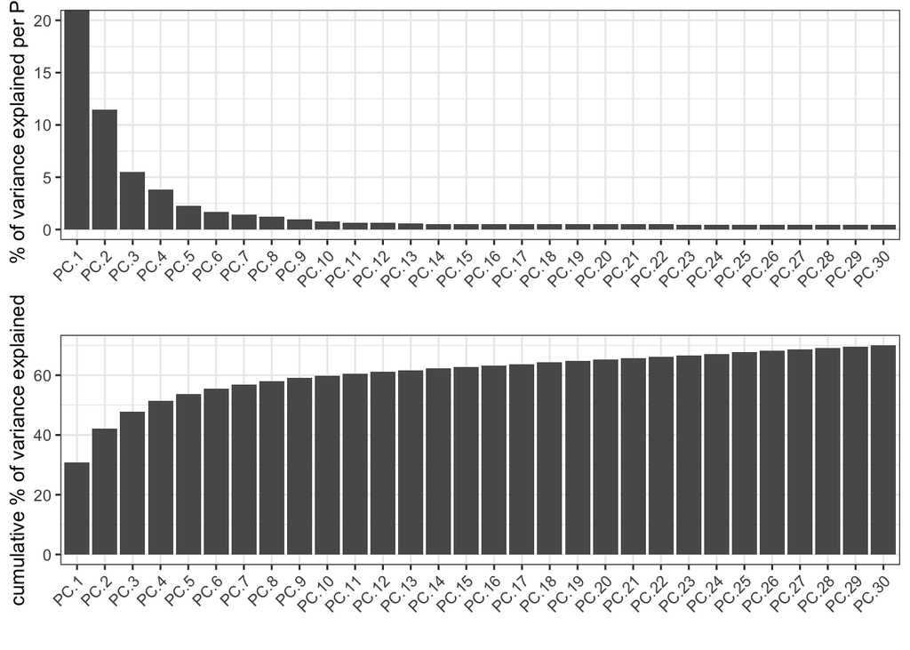

```r
visium_brain <- runPCA(gobject = visium_brain) #resume la matriz de expresión (solo con los HVF) en componentes principales

screePlot(gobject = visium_brain,
          ncp = 30) #muestra cuánta varianza explica cada componente de los primeros 30
```

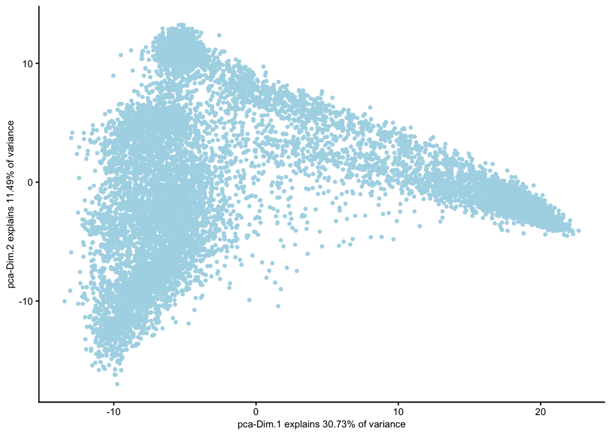

```r
plotPCA(gobject = visium_brain) #grafica los spots en PC1 vs PC2
```

En el scree plot bsucamos el codo: a partir de ahí los componentes aportan poca varianza y probablemente son ruido.

En el PCA, los spots que quedan en grupos pueden tener una estructura biológica.

## 12 UMAP

Calculamos una proyección de los spots usando los primeros 10 componentes principales:

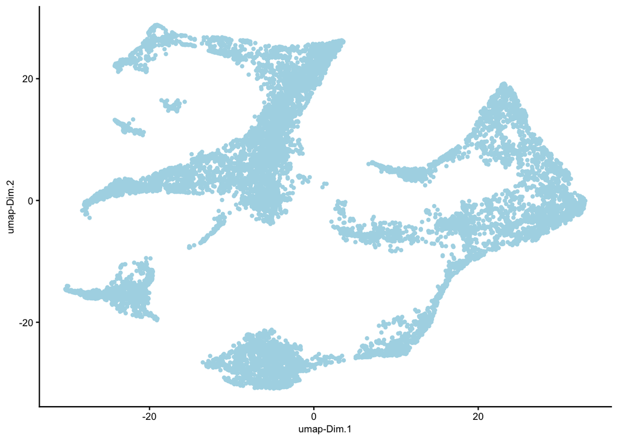

```r
visium_brain <- runUMAP(visium_brain,
                        dimensions_to_use = 1:10) #crea un UMAP, cada punto es un spot los spots que caen juntos son lso que comparten un perfil de expresión génica muy parecido. lo hace sobre los PC para no tener tantas dimensiones por la cantidad de genes pero si guardar su info

plotUMAP(gobject = visium_brain) # imprime el UMAP
```

Spots cercanos en el UMAP tienen perfiles de expresión parecidos (aunque las distancias entre grupos y el tamaño no son cuantificables) y UMAP sirve solo para visualizar.

## 13 tSNE

Ahora otro método de proyección no lineal.

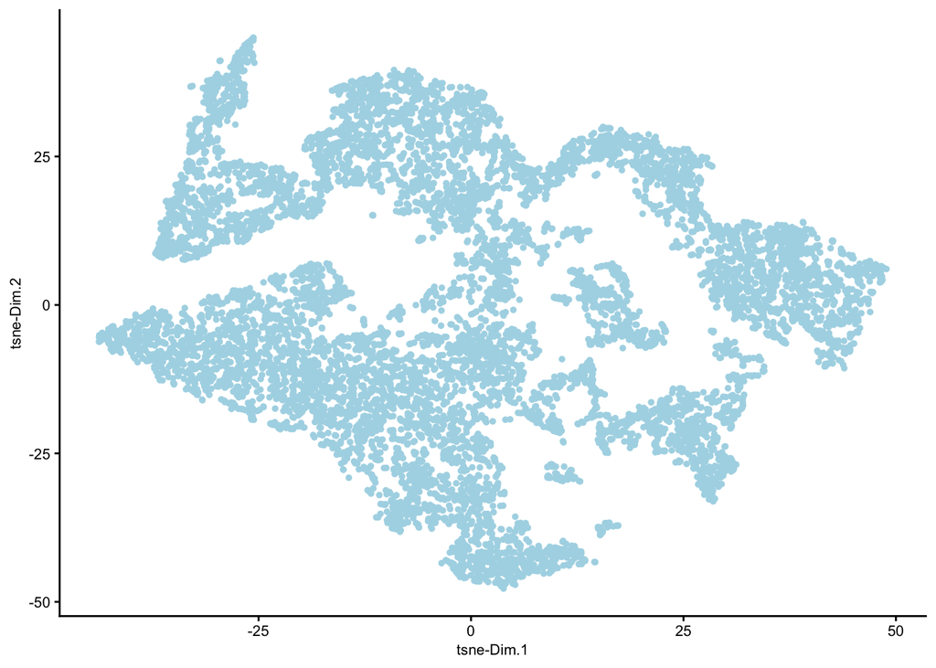

```r
visium_brain <- runtSNE(visium_brain,
                        dimensions_to_use = 1:10)
#similar al UMAP pero agrupa puntos muy cercanos en el espacio original
plotTSNE(gobject = visium_brain)
```

## 14 Vecinos cercanos

Construimos grafos de vecinos entre spots sobre los primeros 10 PCs con k = 15.

```r
#estas son las formas de encontrar a los vecinitos más cercanos segón diferentes métodos

# sNN network (default)
visium_brain <- createNearestNetwork(gobject = visium_brain,
                                     dimensions_to_use = 1:10,
                                     k = 15)

# K-Nearest Neighbors (kNN)
visium_brain <- createNearestNetwork(gobject = visium_brain,
                                     dimensions_to_use = 1:10,
                                     k = 15,
                                     type = "kNN")

#es importante aclarar que se sobreescribe el resultado de sNN ahora en kNN, pues se usa la misma variable. Al agregar kNN, el resultado de sNN se borra y se conserva el de kNN (que es el que usaremos abajo)
```